```python
import pandas as pd
import numpy as np
import matplotlib.pyplot as plt
import matplotlib.font_manager as fm
import seaborn as sns
from sklearn.utils import shuffle
import os
from scipy import stats
from statsmodels.stats.multicomp import pairwise_tukeyhsd
import statsmodels.api as sm
import pylab
from sklearn.ensemble import RandomForestClassifier
from sklearn.model_selection import cross_val_score, cross_val_predict, cross_validate, learning_curve
from sklearn import metrics
from sklearn.preprocessing import StandardScaler, OneHotEncoder, PolynomialFeatures
from sklearn.linear_model import LogisticRegression
from sklearn.model_selection import train_test_split, validation_curve
from sklearn.metrics import confusion_matrix
from sklearn.base import BaseEstimator, TransformerMixin
from sklearn.preprocessing import FunctionTransformer
from sklearn.compose import make_column_selector as selector, ColumnTransformer
from sklearn.pipeline import Pipeline, make_pipeline
from sklearn.preprocessing import LabelEncoder
from sklearn.model_selection import GridSearchCV

plt.style.use('seaborn')

# Fixing random state for reproducibility
np.random.seed(42)
```

```python
OUTPUT_FOLDER = ""
```

Aunque haya alguna explicación, en general este *notebook* solo contiene el código y los resultados utilizados en la documentación.

# Análisis y procesado de los datos

## Análisis preliminar

```python
DATA_FOLDER = os.path.join(os.path.dirname(os.getcwd()), "1. Creación del dataset\\scraper\\data\\tmp")
```

```python
df = pd.read_csv(f"{DATA_FOLDER}\songs.csv", sep=";")
df.head(3).T
```

|  | 0 | 1 | 2 |
| --- | --- | --- | --- |
| title | #첫사랑 | #화이트 스타일 (feat. 김호연 of 달 좋은밤) | %%(응응) |
| singer | bol4 | kisum | apink |
| album | #첫사랑 | show off | percent |
| producer | 쇼파르뮤직, 딩고뮤직 | 스케치 | 플레이엠엔터테인먼트 |
| distributor | 카카오 m | 카카오 m | 카카오 m |
| year_month | 201801-201802-201803 | 201507 | 201901-201902 |
| is_popular | 1 | 0 | 1 |
| external_factors | 0 | 0 | 0 |
| num_times_top_10 | 1 | 0 | 0 |
| num_times_top_5 | 1 | 0 | 0 |
| num_times_top_1 | 0 | 0 | 0 |
| is_collab | False | True | False |
| spotify_uri | 4tKN17Kw29gzlnZwMaAtZN | 1LrcLQ3pTFz7yafs0a2sds | 4SpQDJz1JiRT2mHxvyqN9K |
| album_type | single | single | single |
| release_date | 2018-01-10 | 2015-06-17 | 2019-01-07 |
| duration_ms | 207495 | 191805 | 208104 |
| explicit | False | False | False |
| acousticness | 0.605 | 0.059 | 0.294 |
| danceability | 0.568 | 0.696 | 0.647 |
| energy | 0.646 | 0.93 | 0.855 |
| instrumentalness | 0 | 0 | 0 |
| liveness | 0.131 | 0.194 | 0.137 |
| loudness | -3.418 | -3.5 | -2.944 |
| speechiness | 0.0406 | 0.172 | 0.037 |
| valence | 0.395 | 0.825 | 0.683 |
| tempo | 77.927 | 91.96 | 144.867 |
| singer_id | 4k5fFEYgkWYrYvtOK3zVBl | 1CArfopvfCxakFJHup55FW | 2uWcrwgWmZcQc3IPBs3tfU |
| is_ost | 0 | 0 | 0 |
| for_reality_tvshow | 0 | 0 | 0 |

```python
df.shape
```

```
(3070, 29)
```

Antes de empezar a analizar el *dataset* la variable `year_month` se va a transformar para que los algoritmos puedan utilizarlo.

El atributo `year_month` incluye el año y mes en los que la canción estuvo en el *Gaon chart*. De estos valores se pueden extraer múltiples *features*:

- Número de meses que la canción estuvo en *Gaon*.
- Primer mes y año en el que la canción apareció en el *chart*.

```python
df.year_month.head()
```

```
0    201801-201802-201803
1                  201507
2           201901-201902
3    202003-202004-202005
4                  201105
Name: year_month, dtype: object
```

```python
df['times_in_chart'] = df.year_month.str.count("-") + 1 # número de veces que aparece en el chart
```

```python
year_month_first_time = df.year_month.str.split("-").str[0] # first year and month in chart
year_month_first_time = pd.to_datetime(year_month_first_time, format='%Y%m') # convert to pandas datetime
df['first_time_in_chart_date'] = year_month_first_time

df['first_time_in_chart_year'] = year_month_first_time.dt.year
df['first_time_in_chart_month'] = year_month_first_time.dt.month
df['first_time_in_chart_quarter'] = year_month_first_time.dt.quarter
df['first_time_in_chart_period'] = "other"  # summer (June to August), holiday (November to January)
df.loc[(df.first_time_in_chart_month >= 6) & (df.first_time_in_chart_month <= 8), "first_time_in_chart_period"] = "summer"
df.loc[(df.first_time_in_chart_month >= 11) & (df.first_time_in_chart_month <= 12) | (df.first_time_in_chart_month == 1), "first_time_in_chart_period"] = "holiday"
```

Se descartan las *features* que no se van a utilizar.

```python
df.drop(['year_month', 'release_date', 'external_factors'], axis=1, inplace=True)
```

Las columnas resultantes son las siguientes:

```python
df.columns
```

```
Index(['title', 'singer', 'album', 'producer', 'distributor', 'is_popular',
       'num_times_top_10', 'num_times_top_5', 'num_times_top_1', 'is_collab',
       'spotify_uri', 'album_type', 'duration_ms', 'explicit', 'acousticness',
       'danceability', 'energy', 'instrumentalness', 'liveness', 'loudness',
       'speechiness', 'valence', 'tempo', 'singer_id', 'is_ost',
       'for_reality_tvshow', 'times_in_chart', 'first_time_in_chart_date',
       'first_time_in_chart_year', 'first_time_in_chart_month',
       'first_time_in_chart_quarter', 'first_time_in_chart_period'],
      dtype='object')
```

Se comprueba que los tipos de los datos sean correctos, se corrigen en caso contrario. También se observa que no hay valores null o vacíos (*missing data*).

```python
# Se corrigen los tipos de los datos que no sean correctos
def fix_column_types(df, label=True):
    fix_cat_columns = ["producer", "distributor", "album_type", "first_time_in_chart_period",
                    "is_collab", "explicit", "is_ost", "for_reality_tvshow"]
    if label is True:
        fix_cat_columns += ['is_popular']
    for c in fix_cat_columns:
        df[c] = df[c].astype('category')
        df[c] = df[c].cat.remove_unused_categories()
```

```python
fix_column_types(df)
```

```python
df.info()
```

```
<class 'pandas.core.frame.DataFrame'>
RangeIndex: 3070 entries, 0 to 3069
Data columns (total 32 columns):
 #   Column                       Non-Null Count  Dtype
---  ------                       --------------  -----
 0   title                        3070 non-null   object
 1   singer                       3070 non-null   object
 2   album                        3070 non-null   object
 3   producer                     3070 non-null   category
 4   distributor                  3070 non-null   category
 5   is_popular                   3070 non-null   category
 6   num_times_top_10             3070 non-null   int64
 7   num_times_top_5              3070 non-null   int64
 8   num_times_top_1              3070 non-null   int64
 9   is_collab                    3070 non-null   category
```

[output cut: 24 more lines]

```python
df.describe().T
```

|  | count | mean | std | min | 25% | 50% | 75% | max |
| --- | --- | --- | --- | --- | --- | --- | --- | --- |
| num_times_top_10 | 3070.0 | 0.387622 | 0.745297 | 0.000 | 0.000000 | 0.0000 | 1.000000 | 8.000 |
| num_times_top_5 | 3070.0 | 0.195114 | 0.491746 | 0.000 | 0.000000 | 0.0000 | 0.000000 | 4.000 |
| num_times_top_1 | 3070.0 | 0.039414 | 0.197929 | 0.000 | 0.000000 | 0.0000 | 0.000000 | 2.000 |
| duration_ms | 3070.0 | 224917.784365 | 32974.549357 | 3056.000 | 203721.250000 | 221420.0000 | 240994.500000 | 411713.000 |
| acousticness | 3070.0 | 0.355979 | 0.282459 | 0.000 | 0.088975 | 0.3020 | 0.609000 | 0.990 |
| danceability | 3070.0 | 0.607868 | 0.144445 | 0.000 | 0.505000 | 0.6250 | 0.718750 | 0.936 |
| energy | 3070.0 | 0.674824 | 0.202295 | 0.000 | 0.521000 | 0.7100 | 0.849000 | 0.997 |
| instrumentalness | 3070.0 | 0.009305 | 0.083927 | 0.000 | 0.000000 | 0.0000 | 0.000000 | 0.955 |
| liveness | 3070.0 | 0.190387 | 0.145915 | 0.000 | 0.101000 | 0.1320 | 0.243000 | 0.995 |
| loudness | 3070.0 | -4.986710 | 2.264423 | -23.711 | -6.116750 | -4.7060 | -3.409250 | 0.076 |
| speechiness | 3070.0 | 0.079537 | 0.075863 | 0.000 | 0.034400 | 0.0475 | 0.089375 | 0.625 |
| valence | 3070.0 | 0.500211 | 0.235836 | 0.000 | 0.294500 | 0.4920 | 0.696000 | 0.972 |
| tempo | 3070.0 | 309.301526 | 4784.440611 | 0.000 | 99.933750 | 124.0160 | 135.932750 | 142165.000 |
| times_in_chart | 3070.0 | 1.604235 | 1.425475 | 1.000 | 1.000000 | 1.0000 | 2.000000 | 28.000 |
| first_time_in_chart_year | 3070.0 | 2014.559609 | 3.049745 | 2010.000 | 2012.000000 | 2014.0000 | 2017.000000 | 2020.000 |
| first_time_in_chart_month | 3070.0 | 6.417264 | 3.442896 | 1.000 | 3.000000 | 6.0000 | 9.000000 | 12.000 |
| first_time_in_chart_quarter | 3070.0 | 2.481433 | 1.117479 | 1.000 | 1.000000 | 2.0000 | 3.000000 | 4.000 |

En el campo `duration_ms` se observan valores raros al tener un valor mínimo de 3 segundos. Se ordenan las canciones por su duración de forma ascendente y se comprueban los valores para saber si son válidos.

Tras investigar se conoce que en Spotify la primera canción no está de manera correcta y se borra. El resto de canciones que no duran ni un minuto se han comprobado, y como bien dice el título corresponden a canciones que se suelen utilizar al principio (intro) o al final (outro) de los álbumes. Este tipo de canciones suelen ser más cortas y sirven de introducción por lo que son correctas.

```python
df.sort_values(by=['duration_ms']).head(8)
```

|  | title | singer | album | producer | distributor | is_popular | num_times_top_10 | num_times_top_5 | num_times_top_1 | is_collab | ... | tempo | singer_id | is_ost | for_reality_tvshow | times_in_chart | first_time_in_chart_date | first_time_in_chart_year | first_time_in_chart_month | first_time_in_chart_quarter | first_time_in_chart_period |
| --- | --- | --- | --- | --- | --- | --- | --- | --- | --- | --- | --- | --- | --- | --- | --- | --- | --- | --- | --- | --- | --- |
| 531 | lollipop part 2 | 2ne1 | lollipop part 2 | yg entertainment | stone music entertainment | 1 | 0 | 0 | 0 | False | ... | 0.000 | 1l0mKo96Jh9HVYONcRl3Yp | 0 | 0 | 1 | 2010-03-01 | 2010 | 3 | 1 | other |
| 417 | i i yo (prod. 길 of magic mansion) | gummy | stroke | 씨제스엔터테인먼트 | 카카오 m | 0 | 0 | 0 | 0 | False | ... | 126.076 | 0hRHbwZ0xSwfVHl4FTv7jq | 0 | 0 | 1 | 2017-06-01 | 2017 | 6 | 2 | summer |
| 438 | intro (alive) | bigbang | 빅뱅 미니앨범 5집 alive | yg entertainment | 지니뮤직 | 0 | 0 | 0 | 0 | False | ... | 110.080 | 4Kxlr1PRlDKEB0ekOCyHgX | 0 | 0 | 1 | 2012-02-01 | 2012 | 2 | 1 | other |
| 886 | to be one (outro.) | wanna one | 1-1=0 (nothing without you) | ymc엔터테인먼트, stone music entertainment | stone music entertainment | 0 | 0 | 0 | 0 | False | ... | 175.349 | 2CvaqAMMsX576VBehaJ0Wx | 0 | 0 | 1 | 2017-11-01 | 2017 | 11 | 4 | holiday |
| 657 | nothing without you (intro.) | wanna one | 1-1=0 (nothing without you) | ymc엔터테인먼트, stone music entertainment | stone music entertainment | 0 | 0 | 0 | 0 | False | ... | 166.590 | 2CvaqAMMsX576VBehaJ0Wx | 0 | 0 | 1 | 2017-12-01 | 2017 | 12 | 4 | holiday |
| 410 | i decide | heritage | acoustic ＆ vintage | 스타에비뉴 | 다날 | 0 | 0 | 0 | 0 | False | ... | 115.345 | 2sEpqK4sCyBvx0qFMx052t | 0 | 0 | 1 | 2011-08-01 | 2011 | 8 | 3 | summer |
| 2003 | 비가오네 | geeks | 1집 backpack | wa엔터테인먼트, 그랜드라인엔터테인먼트 | 지니뮤직 | 0 | 0 | 0 | 0 | False | ... | 97.011 | 5VxfguafjfSdJcN10ACVZe | 0 | 0 | 1 | 2013-05-01 | 2013 | 5 | 2 | other |
| 2131 | 사랑하는 그대여 | 4men | 사랑하는 그대여 | ywho & 해피페이스 ent. | universal music | 1 | 0 | 0 | 0 | False | ... | 71.515 | 7oFIkpNpLrTBgZW6w55W1J | 0 | 0 | 1 | 2014-06-01 | 2014 | 6 | 2 | summer |

8 rows × 32 columns

```python
df.drop([531], axis=0, inplace=True) # eliminar canción de 3 segundos
```

También se comprueba la duración de forma descendente, ya que el máximo valor es de casi 7 minutos. Tras comprobar las canciones que más duran no se han encontrado errores, parece que las canciones realmente duran 6 minutos o más.

```python
df.sort_values(by=['duration_ms'], ascending=False).head(8)
```

|  | title | singer | album | producer | distributor | is_popular | num_times_top_10 | num_times_top_5 | num_times_top_1 | is_collab | ... | tempo | singer_id | is_ost | for_reality_tvshow | times_in_chart | first_time_in_chart_date | first_time_in_chart_year | first_time_in_chart_month | first_time_in_chart_quarter | first_time_in_chart_period |
| --- | --- | --- | --- | --- | --- | --- | --- | --- | --- | --- | --- | --- | --- | --- | --- | --- | --- | --- | --- | --- | --- |
| 1088 | 겨울소리 | park hyo shin | 겨울소리 | 글러브엔터테인먼트 | stone music entertainment | 1 | 1 | 0 | 0 | False | ... | 140.947 | 57htMBtzpppc1yoXgjbslj | 0 | 0 | 1 | 2018-01-01 | 2018 | 1 | 1 | holiday |
| 2735 | 잠시만 안녕 (original) | m.c the max | m.c the max! | you & i entertainment | 오감엔터테인먼트 | 0 | 0 | 0 | 0 | False | ... | 74.983 | 3MaRWfwKpbYnkYHC5gRKYo | 0 | 0 | 1 | 2015-02-01 | 2015 | 2 | 1 | other |
| 875 | the ending | nell | slip away | 울림 엔터테인먼트 | 카카오 m | 0 | 0 | 0 | 0 | False | ... | 88.020 | 5WY88tCMFA6J6vqSN3MmDZ | 0 | 0 | 1 | 2012-04-01 | 2012 | 4 | 2 | other |
| 323 | go | nell | slip away | 울림 엔터테인먼트 | 카카오 m | 0 | 0 | 0 | 0 | False | ... | 139.791 | 5WY88tCMFA6J6vqSN3MmDZ | 0 | 0 | 1 | 2012-04-01 | 2012 | 4 | 2 | other |
| 2763 | 좋니 | yoon jong shin | listen 010 좋니 | 미스틱스토리 | 카카오 m | 1 | 5 | 3 | 0 | False | ... | 151.228 | 0hW1muryuCdZLfjoLrUhnw | 0 | 0 | 8 | 2017-07-01 | 2017 | 7 | 3 | summer |
| 2450 | 여러분 (윤복희) | lim jae bum | `나는 가수다` 경연 3-2 (네티즌 추천곡) | 아이엠비씨 | 카카오 m | 1 | 0 | 0 | 0 | False | ... | 73.634 | 7cYFopPCh8aSpBHANLgLaV | 0 | 1 | 1 | 2011-05-01 | 2011 | 5 | 2 | other |
| 382 | home | park hyo shin | i am a dreamer | 글러브엔터테인먼트 | 카카오 m | 1 | 0 | 0 | 0 | False | ... | 114.376 | 57htMBtzpppc1yoXgjbslj | 0 | 0 | 1 | 2016-10-01 | 2016 | 10 | 4 | other |
| 2076 | 사랑에 빠지고 싶다 | johan kim-sep-jung in ji | 사랑에 빠지고 싶다 | 소울패밀리프로덕션 | 카카오 m | 0 | 0 | 0 | 0 | True | ... | 127.734 | 7kqUt0kZIfski1GVmbwjG3-sep-6H4VFmaWST5txEXKqe1w2R | 0 | 0 | 2 | 2011-12-01 | 2011 | 12 | 4 | holiday |

8 rows × 32 columns

Además, los atributos obtenidos de Spotify API parecen estar todos en el rango correspondiente, menos `tempo`. Se comprueba.

```python
df.sort_values(by=['tempo'], ascending=False)[['title', 'singer', 'tempo']].head(8)
```

|  | title | singer | tempo |
| --- | --- | --- | --- |
| 2401 | 어느 멋진 날 | jung yong hwa | 142165.000 |
| 1510 | 널 붙잡을 노래 | rain | 138114.000 |
| 870 | the bad touch (gordon & doyle edit) | dj gollum-sep-empyre one-sep-gordon & doyle | 127941.000 |
| 2420 | 어머니의 된장국 (다이나믹듀오) | 임상아-sep-dynamicduo | 96026.000 |
| 1471 | 너에게 | sung si kyung | 74983.000 |
| 2138 | 사랑한다? 안한다! | f-ve dolls | 208.051 |
| 760 | signal | twice | 207.818 |
| 982 | ya ya ya | exo | 205.177 |

Parece que ha habido problemas de formato al exportar o importar, así que los valores se arreglan.

```python
import spotipy
from spotipy.oauth2 import SpotifyClientCredentials

SPOTIPY_CLIENT_ID='xxxxxxx'
SPOTIPY_CLIENT_SECRET='xxxxxxx'

cut_off = 600

auth_manager = SpotifyClientCredentials(client_id=SPOTIPY_CLIENT_ID,
                                        client_secret=SPOTIPY_CLIENT_SECRET)
sp = spotipy.Spotify(auth_manager=auth_manager)

songs_to_fix = df.loc[df.tempo > cut_off, "spotify_uri"]
songs_to_fix_indexes = songs_to_fix.index

response = sp.audio_features(tracks=songs_to_fix.to_list())
for r,i in zip(response, songs_to_fix_indexes):
  df.loc[i, "tempo"] = r['tempo']
```

```python
df.loc[songs_to_fix_indexes][['title', 'singer', 'tempo']].head(8)
```

|  | title | singer | tempo |
| --- | --- | --- | --- |
| 870 | the bad touch (gordon & doyle edit) | dj gollum-sep-empyre one-sep-gordon & doyle | 127.941 |
| 1471 | 너에게 | sung si kyung | 74.983 |
| 1510 | 널 붙잡을 노래 | rain | 138.114 |
| 2401 | 어느 멋진 날 | jung yong hwa | 142.165 |
| 2420 | 어머니의 된장국 (다이나믹듀오) | 임상아-sep-dynamicduo | 96.026 |

```python
df.to_csv(f"{OUTPUT_FOLDER}songs_analisis.csv", sep=";", index=False)
```

```python
df = pd.read_csv(f"{OUTPUT_FOLDER}songs_analisis.csv", sep=";")
fix_column_types(df)
```

```python
df.describe().T
```

|  | count | mean | std | min | 25% | 50% | 75% | max |
| --- | --- | --- | --- | --- | --- | --- | --- | --- |
| num_times_top_10 | 3069.0 | 0.387748 | 0.745385 | 0.000000 | 0.0000 | 0.0000 | 1.0000 | 8.000 |
| num_times_top_5 | 3069.0 | 0.195178 | 0.491813 | 0.000000 | 0.0000 | 0.0000 | 0.0000 | 4.000 |
| num_times_top_1 | 3069.0 | 0.039427 | 0.197960 | 0.000000 | 0.0000 | 0.0000 | 0.0000 | 2.000 |
| duration_ms | 3069.0 | 224990.075595 | 32735.702157 | 40933.000000 | 203731.0000 | 221430.0000 | 241005.0000 | 411713.000 |
| acousticness | 3069.0 | 0.356095 | 0.282432 | 0.000057 | 0.0895 | 0.3020 | 0.6090 | 0.990 |
| danceability | 3069.0 | 0.608066 | 0.144051 | 0.122000 | 0.5050 | 0.6250 | 0.7190 | 0.936 |
| energy | 3069.0 | 0.675044 | 0.201961 | 0.021100 | 0.5210 | 0.7100 | 0.8490 | 0.997 |
| instrumentalness | 3069.0 | 0.009308 | 0.083940 | 0.000000 | 0.0000 | 0.0000 | 0.0000 | 0.955 |
| liveness | 3069.0 | 0.190449 | 0.145898 | 0.011600 | 0.1010 | 0.1320 | 0.2430 | 0.995 |
| loudness | 3069.0 | -4.985154 | 2.263149 | -23.711000 | -6.1160 | -4.7050 | -3.4080 | 0.076 |
| speechiness | 3069.0 | 0.079563 | 0.075861 | 0.022900 | 0.0344 | 0.0475 | 0.0894 | 0.625 |
| valence | 3069.0 | 0.500374 | 0.235702 | 0.039200 | 0.2960 | 0.4920 | 0.6960 | 0.972 |
| tempo | 3069.0 | 120.855626 | 27.515718 | 47.598000 | 99.9120 | 124.0090 | 135.9080 | 208.051 |
| times_in_chart | 3069.0 | 1.604431 | 1.425666 | 1.000000 | 1.0000 | 1.0000 | 2.0000 | 28.000 |
| first_time_in_chart_year | 3069.0 | 2014.561095 | 3.049130 | 2010.000000 | 2012.0000 | 2014.0000 | 2017.0000 | 2020.000 |
| first_time_in_chart_month | 3069.0 | 6.418377 | 3.442904 | 1.000000 | 3.0000 | 6.0000 | 9.0000 | 12.000 |
| first_time_in_chart_quarter | 3069.0 | 2.481916 | 1.117341 | 1.000000 | 1.0000 | 2.0000 | 3.0000 | 4.000 |

Antes de separar el *dataset* en dos subconjuntos (train y test) se van a explorar las variables que no van a pertenecer a los datos que se usarán en los modelos. Estas variables se exploran por curiosidad.

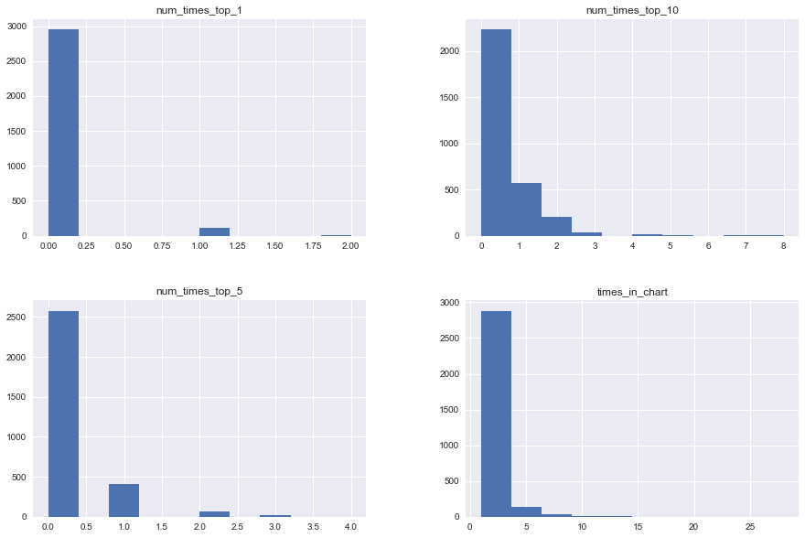

```python
df[['num_times_top_10', 'num_times_top_5', 'num_times_top_1', 'times_in_chart']].hist(
    figsize = (15, 10));
```

Los histogramas muestran lo que ya se intuía, es decir, es más difícil que una canción se mantenga en primera posición de popularidad que entre las 10 primeras. Al mismo tiempo es más difícil que esté entre las 5 primeras que esté entre las 10 primeras.

Por otro lado, es más común que las canciones duren poco en el *chart*. La duración media es de aproximadamente un mes.

Se investiga que canciones estuvieron dos meses en el número 1 de popularidad.

```python
df[df.num_times_top_1 == 2][['title', 'singer', 'is_ost', 'first_time_in_chart_year', 'first_time_in_chart_month']]
```

|  | title | singer | is_ost | first_time_in_chart_year | first_time_in_chart_month |
| --- | --- | --- | --- | --- | --- |
| 2446 | 에잇 (prod.&feat. suga of bts) | iu-sep-suga | 0 | 2020 | 5 |
| 2862 | 첫눈처럼 너에게 가겠다 | ailee | 1 | 2017 | 1 |

## Problema balanceado

Una vez analizados estos atributos se descartan, ya que como se ha indicado previamente tres de ellos conllevan *data leakage* y el otro (times_in_chart) no pertenece al problema que se quiere resolver.

```python
df.drop(['num_times_top_10', 'num_times_top_5', 'num_times_top_1', 'times_in_chart'], axis=1, inplace=True)
```

Se comprueba si la clase `is_popular` está balanceada. No está balanceada pero la diferencia es mínima, por lo que en un principio se considera como problema balanceado. En futuro se podrían utilizar algoritmos (por ejemplo, SMOTE) para balancear los datos.

```python
df['is_popular'].value_counts(normalize=True)
```

```
1    0.550668
0    0.449332
Name: is_popular, dtype: float64
```

```python
df['is_popular'].value_counts()
```

```
1    1690
0    1379
Name: is_popular, dtype: int64
```

## Creación del conjunto de test

```python
# Los datos se mezclan
df = shuffle(df, random_state = 42).reset_index(drop=True)
```

```python
train_rand_X, test_rand_X, train_rand_y, test_rand_y = train_test_split(df.drop('is_popular', axis=1), df['is_popular'],
                                                    random_state = 42,
                                                     test_size=0.20)
```

```python
train_strat_X, test_strat_X, train_strat_y, test_strat_y = train_test_split(df.drop('is_popular', axis=1),
                                                                            df['is_popular'],
                                                    random_state = 42,
                                                    stratify=df['is_popular'],
                                                     test_size=0.20)
```

```python
print(f"Train tienen {train_rand_X.shape[0]} instances")
```

```
Train tienen 2455 instances
```

```python
print(f"Test tienen {test_rand_X.shape[0]} instances")
```

```
Test tienen 614 instances
```

```python
train_rand_y.value_counts(normalize=True)
```

```
1    0.547862
0    0.452138
Name: is_popular, dtype: float64
```

```python
test_rand_y.value_counts(normalize=True)
```

```
1    0.561889
0    0.438111
Name: is_popular, dtype: float64
```

```python
train_strat_y.value_counts(normalize=True)
```

```
1    0.550713
0    0.449287
Name: is_popular, dtype: float64
```

```python
test_strat_y.value_counts(normalize=True)
```

```
1    0.550489
0    0.449511
Name: is_popular, dtype: float64
```

Los porcentajes de las clases son muy similares entre las hechas con stratification y las sin.

```python
train_X = train_strat_X
train_y = train_strat_y
test_X = test_strat_X
test_y = test_strat_y
```

## Exploración y análisis (EDA)

La exploración y el análisis de los datos se realiza sobre el conjunto de entrenamiento.

```python
train_X.info()
```

```
<class 'pandas.core.frame.DataFrame'>
Int64Index: 2455 entries, 2030 to 1381
Data columns (total 27 columns):
 #   Column                       Non-Null Count  Dtype
---  ------                       --------------  -----
 0   title                        2455 non-null   object
 1   singer                       2455 non-null   object
 2   album                        2455 non-null   object
 3   producer                     2455 non-null   category
 4   distributor                  2455 non-null   category
 5   is_collab                    2455 non-null   category
 6   spotify_uri                  2455 non-null   object
 7   album_type                   2455 non-null   category
 8   duration_ms                  2455 non-null   int64
 9   explicit                     2455 non-null   category
```

[output cut: 19 more lines]

```python
cat_features = ['is_collab', 'album_type', 'explicit', 'is_ost',
                'for_reality_tvshow', 'first_time_in_chart_period']
cat_features_long = ['distributor', 'producer']
num_features = ['duration_ms', 'acousticness', 'danceability', 'energy',
                'instrumentalness', 'liveness', 'loudness',
               'speechiness', 'valence', 'tempo']
num_discrete_features = ['first_time_in_chart_year',
                         'first_time_in_chart_month',
                         'first_time_in_chart_quarter']
```

Hacer que el coreano se muestre correctamente en los gráficos.

```python
# Get font so korean text is shown, install it
import urllib.request
url = 'https://fonts.google.com/download?family=Nanum%20Gothic'
file = "NanumGothic.zip"
urllib.request.urlretrieve(url, file)
```

```
('NanumGothic.zip', <http.client.HTTPMessage at 0x17f0ea44e08>)
```

```python
import patoolib
patoolib.extract_archive(file, outdir=".")
```

```python
os.remove(file)
```

```python
path = 'NanumGothic-Regular.ttf'
fontprop = fm.FontProperties(fname=path, size=18)
```

```python
def draw_graphs(df, graph='hist', width=15, height=15, cols=1, ylabel='count', **kwargs):
  # Dibujar los distintos tipos de gráficos

    fig = plt.figure(1, (width, height))
    rows = len(df.describe().columns)

    i = 1

    for col in df.describe().columns:
        ax = plt.subplot(rows, cols, i)
        if graph=="hist":
            sns.histplot(data=df, x=col, kde=True)
        elif graph == "bar":
            order = None
            if kwargs.get("ordered", None):
                order = df[col].value_counts().index
            ax = sns.countplot(x=col, data=df, color=kwargs.get("color", 'steelblue'),
                               order = order, hue=kwargs.get("hue", None))

            # ax.bar(df[col].value_counts().index, df[col].value_counts().values)
            if kwargs.get("korean_ticks", None):
                plt.xticks(fontproperties=fontprop,
                           fontsize=12, rotation=90)
        elif graph == "outliers":
            ax.boxplot(df[col], vert=False)

        elif graph == "boxplot":
            sns.boxplot(x=kwargs.get("train_y", None), y=col, data=df)

        elif graph == "scatterplot":
            sns.scatterplot(data=df, x=kwargs.get("x",None), y=col)

        ax.set_xlabel(col, fontproperties=fontprop)
        ax.set_ylabel(ylabel, fontproperties=fontprop)

        i += 1

        plt.tight_layout()
```

### Análisis univariable

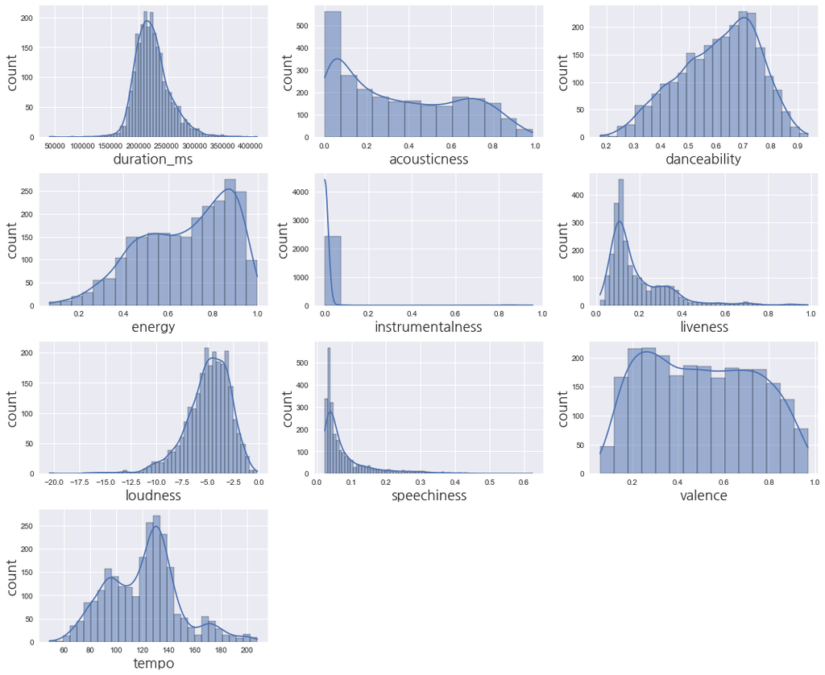

```python
draw_graphs(train_X[num_features], width=15, height=30, cols=3)
```

```python
# test de Shapiro-Wilk
for f in num_features:
    shapiro_test = stats.shapiro(train_X[f].to_list())
    print(f"Feature {f} -- Statistics {shapiro_test.statistic} -- pValue {shapiro_test.pvalue}")
```

```
Feature duration_ms -- Statistics 0.9495927691459656 -- pValue 2.974873244123161e-28
Feature acousticness -- Statistics 0.9159756898880005 -- pValue 6.609871889380288e-35
Feature danceability -- Statistics 0.979364812374115 -- pValue 2.1370401376848357e-18
Feature energy -- Statistics 0.9528588652610779 -- pValue 1.953970136226553e-27
Feature instrumentalness -- Statistics 0.07931166887283325 -- pValue 0.0
Feature liveness -- Statistics 0.7737354040145874 -- pValue 0.0
Feature loudness -- Statistics 0.9387229084968567 -- pValue 1.0426711063827623e-30
Feature speechiness -- Statistics 0.683890163898468 -- pValue 0.0
Feature valence -- Statistics 0.9614085555076599 -- pValue 4.542642703725487e-25
Feature tempo -- Statistics 0.9802669882774353 -- pValue 5.807801757628237e-18
```

```
duration_ms
```

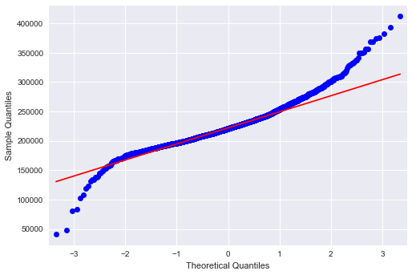

```
####################
acousticness
```

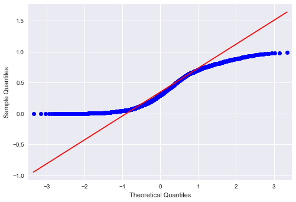

```
####################
danceability
```

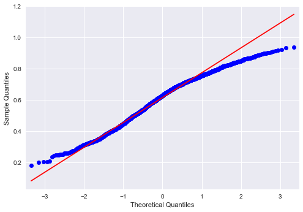

```
####################
energy
```

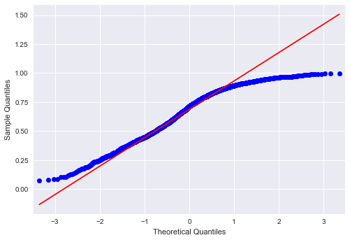

```
####################
instrumentalness
```

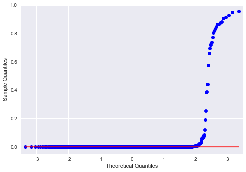

```
####################
liveness
```

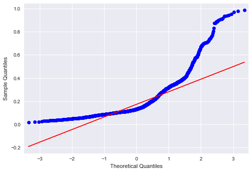

```
####################
loudness
```

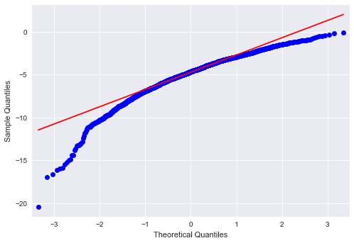

```
####################
speechiness
```

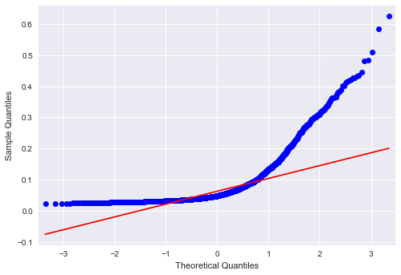

```
####################
valence
```

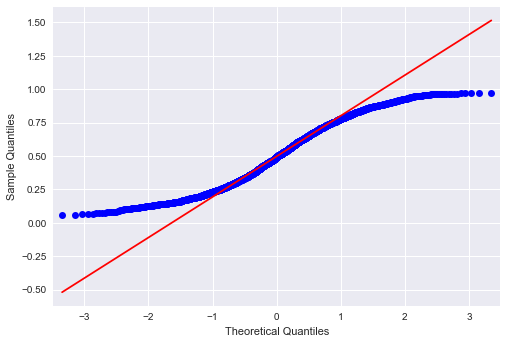

```
####################
tempo
```

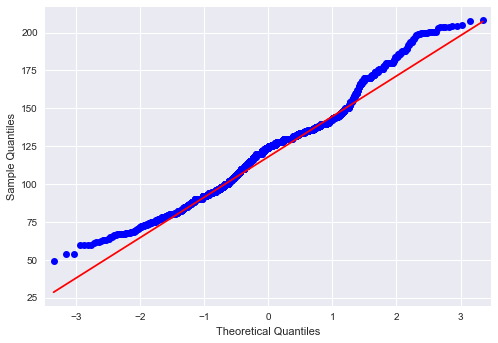

```
####################
```

```python
# Dibujar gráficos QQ-Plot para cada atributo numérico
for f in num_features:
    data = train_X[f]
    print(f)
    sm.qqplot(data, line='q')
    pylab.show()
    print("#"*20)
```

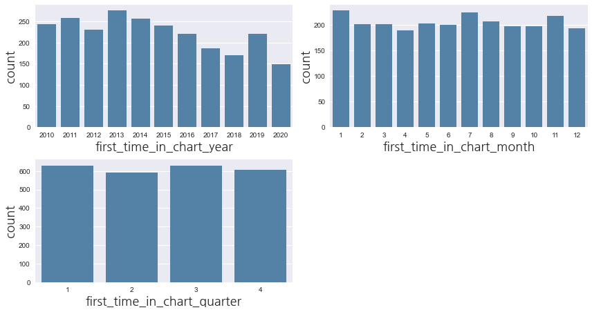

```python
draw_graphs(train_X[num_discrete_features], graph='bar', width=12, height=9, cols=2)
```

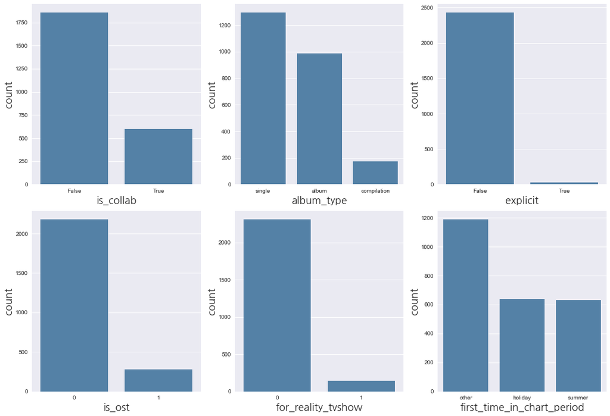

```python
draw_graphs(train_X[cat_features], graph='bar', width=15, height=30, cols=3, ordered=True)
```

```python
fix_column_types(train_X,label=False)
```

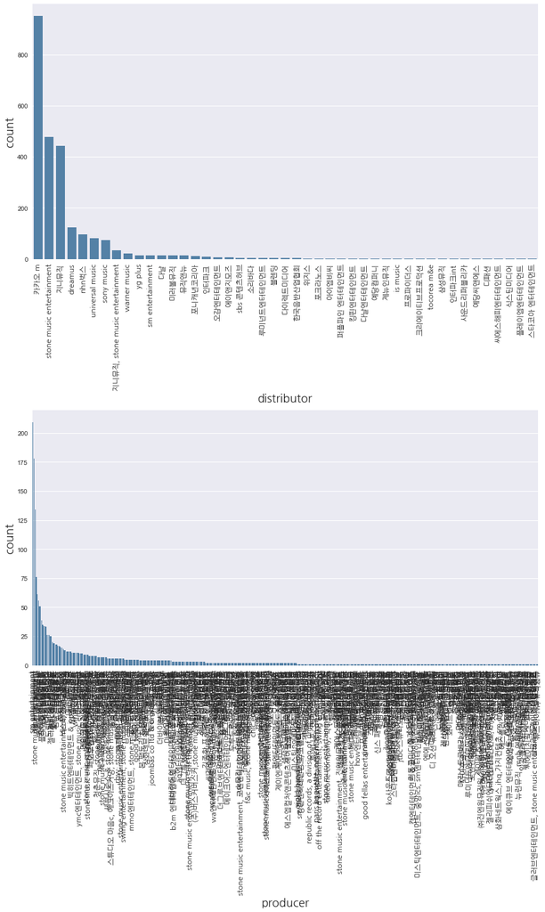

```python
draw_graphs(train_X[cat_features_long], graph='bar', width=12, height=20, cols=1, korean_ticks=True, ordered=True)
```

```python
train_X['producer'].value_counts()[:20]
```

```
sm entertainment             209
yg entertainment             178
stone music entertainment    134
jyp entertainment             76
큐브엔터테인먼트                      61
카카오 m                         56
아메바컬쳐                         51
빅히트 엔터테인먼트                    51
스타쉽엔터테인먼트                     39
플레이엠엔터테인먼트                    35
fnc엔터테인먼트                     34
아이엠비씨                         34
sbs 콘텐츠허브                     33
플레디스                          26
코어컨텐츠미디어                      26
드림티 엔터테인먼트                    26
mbc                           25
젤리피쉬 엔터테인먼트                   25
ymc엔터테인먼트                     20
쇼파르뮤직                         19
Name: producer, dtype: int64
```

```python
train_X['producer'].value_counts()[20:]
```

```
울림 엔터테인먼트                                       19
냠냠엔터테인먼트                                        18
브랜뉴뮤직                                           18
세븐시즌스                                           17
로엔트리                                            17
                                                ..
글로웍스                                             1
글로리엠케이엔터테인먼트                                     1
글러브엔터테인먼트, stone music entertainment, 화앤담픽쳐스     1
블루브릿지                                            1
뮤즈바이유, 뮤직앤뉴                                      1
Name: producer, Length: 449, dtype: int64
```

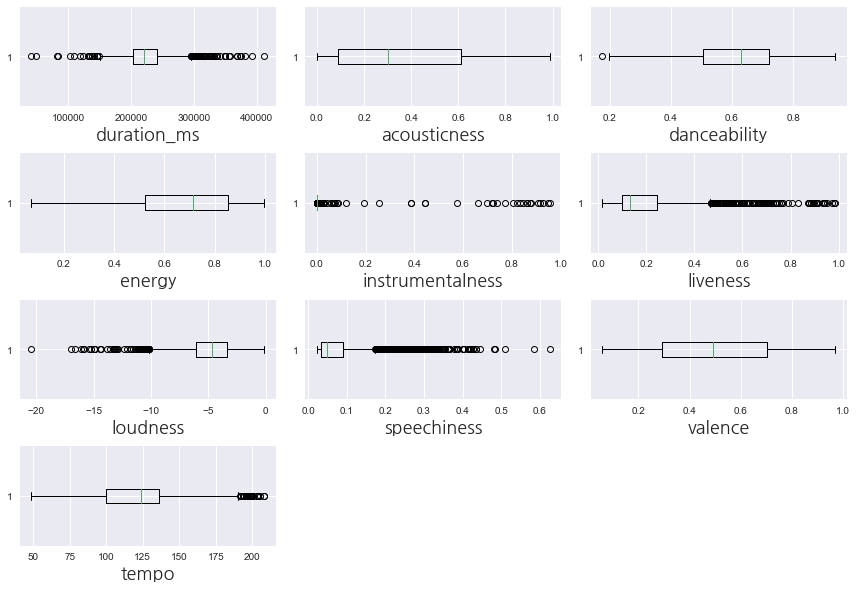

```python
draw_graphs(train_X[num_features], graph='outliers', width=12, height=20, cols=3, ylabel=None)
```

```python
train_X['instrumentalness'].value_counts()
```

```
0.000000    1897
0.000002       4
0.000002       4
0.000001       4
0.000001       3
            ...
0.662000       1
0.000034       1
0.000003       1
0.000002       1
0.000003       1
Name: instrumentalness, Length: 475, dtype: int64
```

```python
train_X[train_X['danceability'] < 0.2].T
```

|  | 1681 | 495 |
| --- | --- | --- |
| title | cliff parade | 난 별 |
| singer | nell | lee so ra |
| album | slip away | 8 |
| producer | 울림 엔터테인먼트 | 세이렌 |
| distributor | 카카오 m | universal music |
| is_collab | False | False |
| spotify_uri | 57LDDVIHY6ZupW1uVvNa8b | 7ojuL7eyypBcHGmHqSzFBv |
| album_type | album | album |
| duration_ms | 273426 | 228000 |
| explicit | False | False |
| acousticness | 0.00817 | 0.0432 |
| danceability | 0.199 | 0.177 |
| energy | 0.914 | 0.559 |
| instrumentalness | 0.821 | 1.76e-05 |
| liveness | 0.228 | 0.11 |
| loudness | -3.524 | -4.901 |
| speechiness | 0.0523 | 0.0323 |
| valence | 0.264 | 0.0588 |
| tempo | 123.994 | 179.979 |
| singer_id | 5WY88tCMFA6J6vqSN3MmDZ | 58BWh3yJrluDugLv0QF0eC |
| is_ost | 0 | 0 |
| for_reality_tvshow | 0 | 0 |
| first_time_in_chart_date | 2012-04-01 | 2014-04-01 |
| first_time_in_chart_year | 2012 | 2014 |
| first_time_in_chart_month | 4 | 4 |
| first_time_in_chart_quarter | 2 | 2 |
| first_time_in_chart_period | other | other |

Se obtienen los outliers de `loudness` y `speechiness` para analizarlos. Se analizan los valores más bajos de `loudness` y los valores más altos de `speechiness`.

```python
def get_outliers(train_X, c):
    # Values < Q1-1.5*IQR or > Q3+1.5*IQR are treated as outliers

    Q1 = train_X[c].quantile(0.25)
    Q3 = train_X[c].quantile(0.75)
    IQR = Q3 - Q1
    lower = Q1-1.5*IQR
    upper = Q3+1.5*IQR
    return IQR, lower, upper
```

```python
iqr, lower, upper = get_outliers(train_X, "loudness")
train_X[train_X["loudness"] < lower].sort_values('loudness', ascending=True).head(4).T
```

|  | 2565 | 1278 | 439 | 2027 |
| --- | --- | --- | --- | --- |
| title | i i yo (prod. 길 of magic mansion) | 우리 서로 | 숨 | 마음대로 |
| singer | gummy | music for u | park hyo shin | lee jin ah |
| album | stroke | 우리 서로 | i am a dreamer | k팝 스타 시즌4 `마음대로` |
| producer | 씨제스엔터테인먼트 | 네버랜드엔터테인먼트 | 글러브엔터테인먼트 | sbs 콘텐츠허브 |
| distributor | 카카오 m | 카카오 m | 카카오 m | 카카오 m |
| is_collab | False | False | False | False |
| spotify_uri | 1B8bsQPShrel4cEPn1Ce8c | 7HJLXGUNHHAczacDtOe52a | 1i08Mj6xQocwfIHQ03ATR1 | 5VNlvzFwpdWgMYjKibcfA2 |
| album_type | album | album | single | single |
| duration_ms | 40933 | 243636 | 282958 | 180186 |
| explicit | False | False | False | False |
| acousticness | 0.776 | 0.207 | 0.981 | 0.936 |
| danceability | 0.398 | 0.493 | 0.561 | 0.603 |
| energy | 0.154 | 0.216 | 0.0837 | 0.0779 |
| instrumentalness | 0.948 | 0.864 | 0.907 | 0 |
| liveness | 0.121 | 0.27 | 0.111 | 0.11 |
| loudness | -20.434 | -16.967 | -16.611 | -16.134 |
| speechiness | 0.0315 | 0.028 | 0.0369 | 0.0877 |
| valence | 0.496 | 0.0761 | 0.11 | 0.188 |
| tempo | 126.076 | 132.037 | 71.451 | 103.015 |
| singer_id | 0hRHbwZ0xSwfVHl4FTv7jq | 2QOzWdsMtYoTxENFZmf7Vz | 57htMBtzpppc1yoXgjbslj | 4SzO3ea2qcjg1uLyNJAWnM |
| is_ost | 0 | 0 | 0 | 0 |
| for_reality_tvshow | 0 | 0 | 0 | 1 |
| first_time_in_chart_date | 2017-06-01 | 2018-05-01 | 2016-09-01 | 2014-12-01 |
| first_time_in_chart_year | 2017 | 2018 | 2016 | 2014 |
| first_time_in_chart_month | 6 | 5 | 9 | 12 |
| first_time_in_chart_quarter | 2 | 2 | 3 | 4 |
| first_time_in_chart_period | summer | other | other | holiday |

```python
train_X.sort_values('loudness', ascending=False).head(1)
```

|  | title | singer | album | producer | distributor | is_collab | spotify_uri | album_type | duration_ms | explicit | ... | valence | tempo | singer_id | is_ost | for_reality_tvshow | first_time_in_chart_date | first_time_in_chart_year | first_time_in_chart_month | first_time_in_chart_quarter | first_time_in_chart_period |
| --- | --- | --- | --- | --- | --- | --- | --- | --- | --- | --- | --- | --- | --- | --- | --- | --- | --- | --- | --- | --- | --- |
| 1748 | 미치겠어 | teen top | it`s | 티오피미디어 | 카카오 m | False | 6pAHK5QCjpqIE72udOhvhb | single | 195375 | False | ... | 0.311 | 159.872 | 3offPqpKAKmpQkIdWnjzkc | 0 | 0 | 2012-01-01 | 2012 | 1 | 1 | holiday |

1 rows × 27 columns

```python
iqr, lower, upper = get_outliers(train_X, "speechiness")
train_X[train_X["speechiness"] > upper].sort_values('speechiness', ascending=False).head(4).T
```

|  | 537 | 1185 | 1065 | 1731 |
| --- | --- | --- | --- | --- |
| title | 아름다워 (beautiful) (feat. 지코 (zico)) | 있어줘 (feat. lydia paek) | i am | interlude _ shadow |
| singer | c jamm-sep-zico | dynamicduo-sep-lydia paek | iron | bts |
| album | 쇼미더머니 5 episode 4 | grand carnival | 쇼미더머니3 part 1 | map of the soul _ 7 |
| producer | stone music entertainment | 아메바컬쳐 | stone music entertainment | 빅히트 엔터테인먼트 |
| distributor | stone music entertainment | 카카오 m | stone music entertainment | dreamus |
| is_collab | True | True | False | False |
| spotify_uri | 3VzoaIJhDDnMgXqPLZgJb5 | 7Dru1fbOhXYaSqSffblgp1 | 7B7juUvkVza0u6lZV8uMPk | 2Nib4r0saYQf2pUV4RFDhl |
| album_type | single | album | single | album |
| duration_ms | 265806 | 224263 | 179583 | 259821 |
| explicit | False | False | True | False |
| acousticness | 0.232 | 0.193 | 0.0405 | 0.115 |
| danceability | 0.515 | 0.427 | 0.703 | 0.385 |
| energy | 0.96 | 0.831 | 0.74 | 0.798 |
| instrumentalness | 0 | 0 | 0 | 0 |
| liveness | 0.148 | 0.164 | 0.358 | 0.181 |
| loudness | -3.106 | -5.242 | -5.687 | -6.439 |
| speechiness | 0.625 | 0.585 | 0.509 | 0.483 |
| valence | 0.144 | 0.624 | 0.327 | 0.141 |
| tempo | 80.547 | 166.894 | 82.629 | 149.756 |
| singer_id | 2ZT3bnHPOdErwCLdP5aHqR-sep-4XpUIb8uuNlIWVKmgKZXC0 | 4nvFFLtv7ZqoTr83387uK4-sep-7lWvLu7PmQ20FqmMhgqFGN | 2IQN0IrTeIM0xhtiFAK9Ed | 3Nrfpe0tUJi4K4DXYWgMUX |
| is_ost | 0 | 0 | 0 | 0 |
| for_reality_tvshow | 1 | 0 | 1 | 0 |
| first_time_in_chart_date | 2016-07-01 | 2015-11-01 | 2014-09-01 | 2020-07-01 |
| first_time_in_chart_year | 2016 | 2015 | 2014 | 2020 |
| first_time_in_chart_month | 7 | 11 | 9 | 7 |
| first_time_in_chart_quarter | 3 | 4 | 3 | 3 |
| first_time_in_chart_period | summer | holiday | other | summer |

### Análisis bivariable

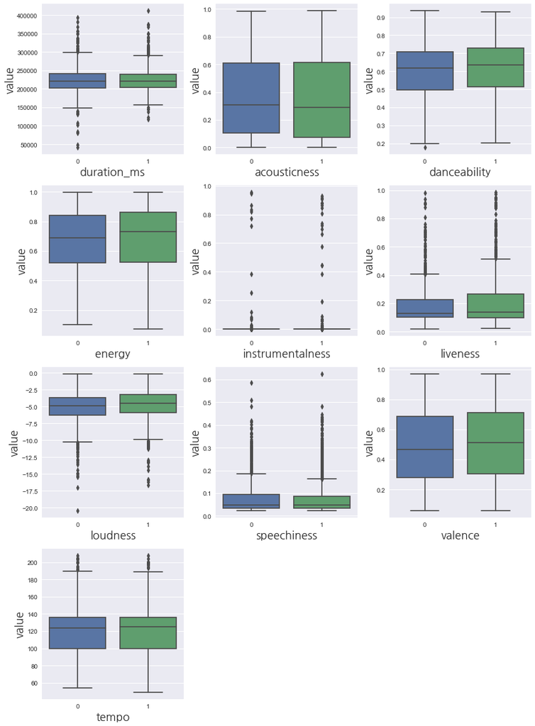

```python
# bivariables de las num con la target
draw_graphs(train_X[num_features], graph='boxplot', width=12, height=40, cols=3, train_y=train_y, ylabel='value')
```

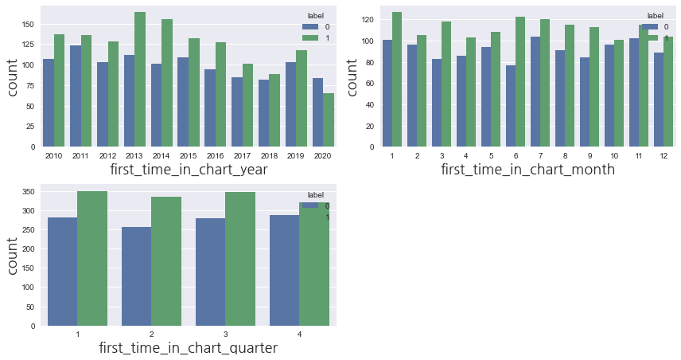

```python
tmp = train_X[num_discrete_features].copy()
tmp["label"] = train_y
draw_graphs(tmp, graph='bar', width=12, height=9, cols=2, hue="label", color=None)
```

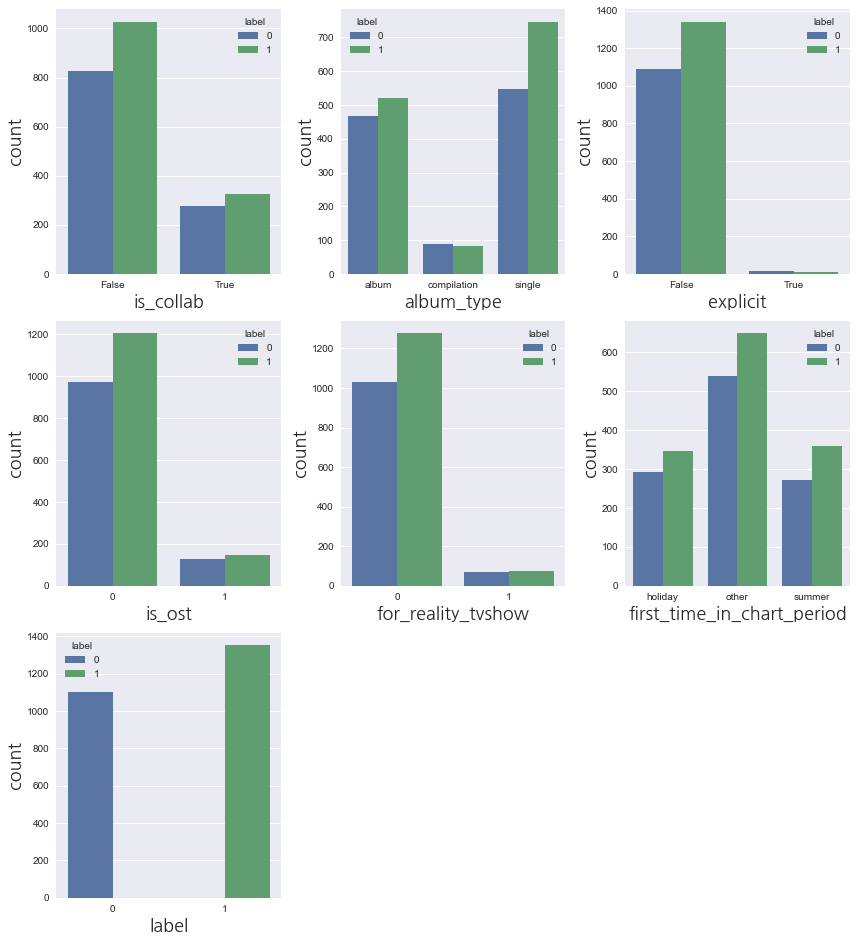

```python
tmp = train_X[cat_features].copy()
tmp["label"] = train_y
draw_graphs(tmp, graph='bar', width=12, height=30, cols=3, hue='label', color=None)
```

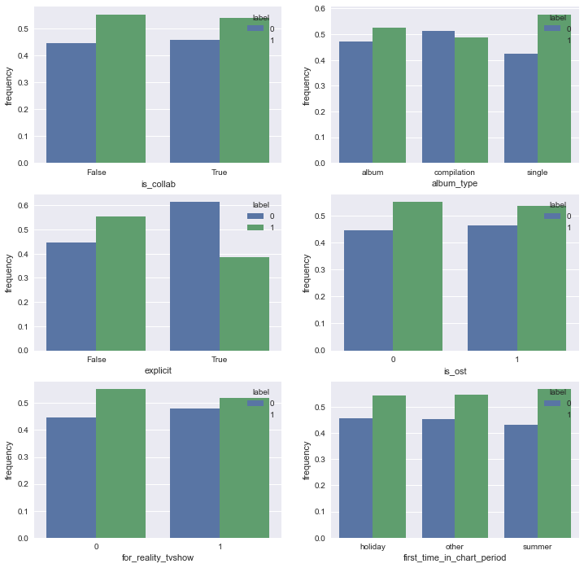

```python
# Los valores están en porcentaje sobre 100% (frecuencias)
fig, axes = plt.subplots(3, 2, figsize=(12, 12))
tmp['frequency'] = 0
for col, ax in zip(cat_features, axes.flatten()):
    counts = tmp.groupby([col, 'label']).count()
    freq_per_group = counts.div(counts.groupby(col).transform('sum')).reset_index()
    sns.barplot(x=col, y='frequency', hue='label', data=freq_per_group, ax=ax)
```

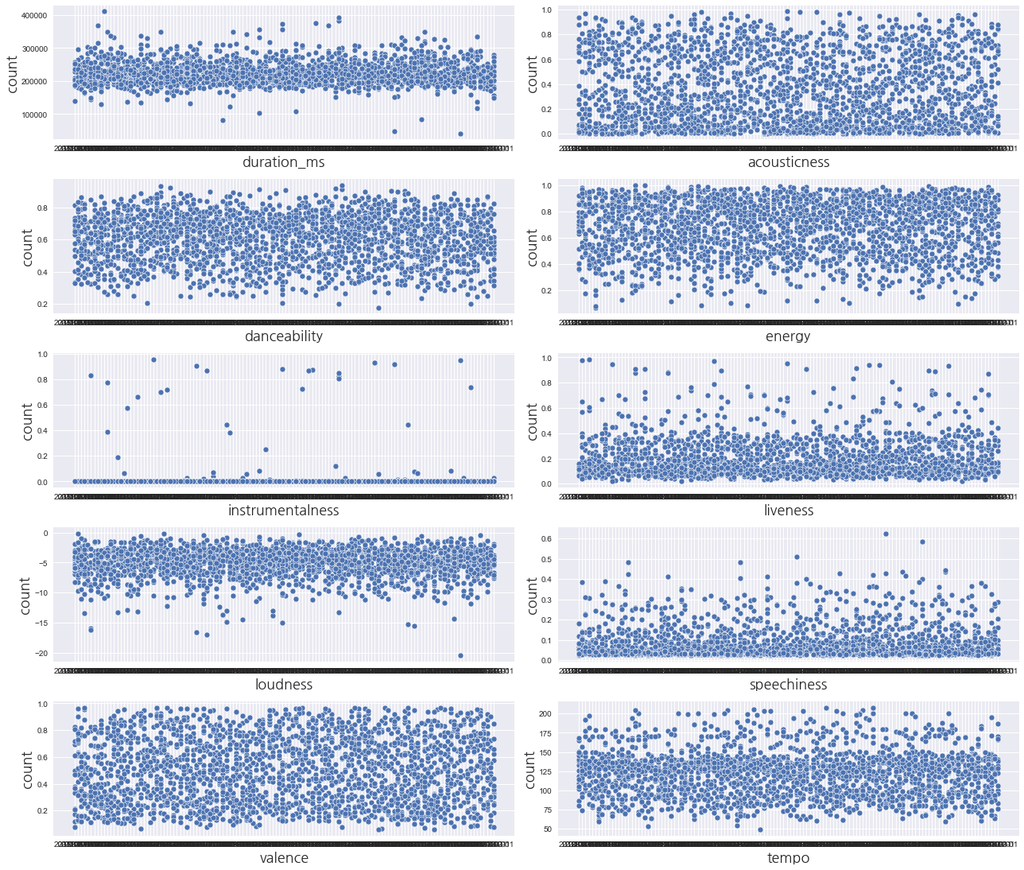

```python
draw_graphs(train_X[num_features + ['first_time_in_chart_date']], graph='scatterplot',
            width=18, height=30, cols=2, x="first_time_in_chart_date")
```

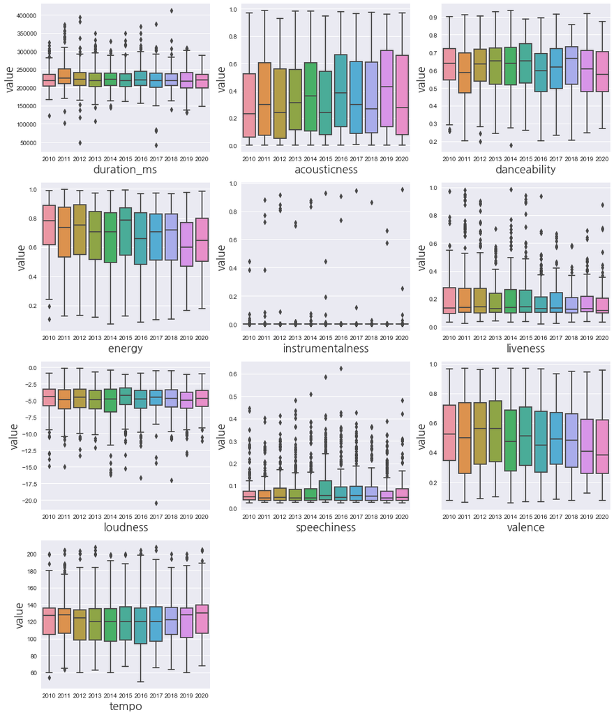

```python
draw_graphs(train_X[num_features], graph='boxplot', width=14, height=40, cols=3,
            train_y=train_X['first_time_in_chart_year'], ylabel='value')
```

### Las canciones populares son más bailables y tienen más energía que las no populares

```python
# Contraste de hipótesis de dos muestras sobre la diferencia de medias
features = ['danceability', 'energy']
for f in features:
    populares = train_X[train_y==1][f]
    no_populares = train_X[train_y==0][f]

    media_popular = populares.mean()
    media_no_popular = no_populares.mean()
    varianza_popular = populares.var()
    varianza_no_popular = no_populares.var()
    num_popular = len(populares)
    num_no_popular = len(no_populares)

    numerador = media_popular - media_no_popular
    denominador = np.sqrt((varianza_popular/num_popular)
                          + (varianza_no_popular/num_no_popular))

    estadistico = numerador / denominador
    pvalue = stats.norm.sf(estadistico)

    print(f"Feature {f} -- estadistico {estadistico} -- pvalue {pvalue}")
```

```
Feature danceability -- estadistico 2.8999298956001263 -- pvalue 0.0018662306415185752
Feature energy -- estadistico 2.7047217502337237 -- pvalue 0.0034180812549466843
```

### La música K-Pop varía en el tiempo

```python
# Test Barlett varianzas iguales
years = [2010, 2013, 2016, 2019] # de tres en tres
data_by_year = []
features = ["danceability", "valence", "energy", "acousticness", "loudness"]

for y in years:
    data_by_year.append(train_X[train_X["first_time_in_chart_year"] == y])

for f in features:
    stat, p = stats.bartlett(data_by_year[0][f], data_by_year[1][f],
                             data_by_year[2][f], data_by_year[3][f])
    print(f"Feature {f} -- pValue {p}")
```

```
Feature danceability -- pValue 0.6560001665560415
Feature valence -- pValue 0.22418716281654208
Feature energy -- pValue 0.31340350464782135
Feature acousticness -- pValue 0.14757791296333186
Feature loudness -- pValue 0.17796002080881546
```

```python
# ANOVA
for f in features:
    stat, p = stats.f_oneway(data_by_year[0][f], data_by_year[1][f],
                             data_by_year[2][f], data_by_year[3][f])
    print(f"Feature {f} -- pValue {p}")
```

```
Feature danceability -- pValue 0.006814621108485117
Feature valence -- pValue 1.0829003006146702e-05
Feature energy -- pValue 1.4400790703983002e-11
Feature acousticness -- pValue 4.1177220682554996e-05
Feature loudness -- pValue 0.15553794159605044
```

```python
# Tukey multiple comparisons of means
filter_by_years = train_X[train_X['first_time_in_chart_year'].isin(years)]

for f in features:
    values = filter_by_years[f]
    groups = filter_by_years['first_time_in_chart_year']

    m_comp = pairwise_tukeyhsd(endog=values, groups=groups, alpha=0.05)
    print("Feature ", f)
    print(m_comp)
    print()
    print()
```

```
Feature  danceability
Multiple Comparison of Means - Tukey HSD, FWER=0.05
===================================================
group1 group2 meandiff p-adj   lower  upper  reject
---------------------------------------------------
  2010   2013   0.0051    0.9 -0.0278 0.0379  False
  2010   2016  -0.0357 0.0414 -0.0704 -0.001   True
  2010   2019  -0.0213 0.3923  -0.056 0.0134  False
  2013   2016  -0.0407 0.0105 -0.0745 -0.007   True
  2013   2019  -0.0264 0.1846 -0.0601 0.0074  False
  2016   2019   0.0144 0.7016 -0.0212 0.0499  False
---------------------------------------------------


Feature  valence
Multiple Comparison of Means - Tukey HSD, FWER=0.05
====================================================
group1 group2 meandiff p-adj   lower   upper  reject
----------------------------------------------------
  2010   2013   0.0145 0.8907 -0.0386  0.0675  False
  2010   2016  -0.0603 0.0294 -0.1163 -0.0042   True
  2010   2019  -0.0763 0.0027 -0.1323 -0.0202   True
  2013   2016  -0.0747 0.0025 -0.1292 -0.0203   True
  2013   2019  -0.0908  0.001 -0.1452 -0.0363   True
  2016   2019   -0.016 0.8819 -0.0734  0.0414  False
----------------------------------------------------


Feature  energy
Multiple Comparison of Means - Tukey HSD, FWER=0.05
====================================================
group1 group2 meandiff p-adj   lower   upper  reject
----------------------------------------------------
  2010   2013  -0.0581 0.0031 -0.1013  -0.015   True
  2010   2016  -0.0895  0.001 -0.1351 -0.0439   True
  2010   2019  -0.1262  0.001 -0.1718 -0.0806   True
  2013   2016  -0.0314  0.263 -0.0758  0.0129  False
  2013   2019  -0.0681  0.001 -0.1124 -0.0237   True
  2016   2019  -0.0367 0.1815 -0.0834  0.0101  False
----------------------------------------------------
```

[output cut: 13 more lines]

```
---------------------------------------------------


Feature  loudness
Multiple Comparison of Means - Tukey HSD, FWER=0.05
===================================================
group1 group2 meandiff p-adj   lower  upper  reject
---------------------------------------------------
  2010   2013  -0.1643  0.791 -0.6445 0.3159  False
  2010   2016   -0.277 0.4965 -0.7845 0.2304  False
  2010   2019  -0.4363 0.1207 -0.9437 0.0712  False
  2013   2016  -0.1127    0.9  -0.606 0.3805  False
  2013   2019   -0.272 0.4882 -0.7652 0.2213  False
  2016   2019  -0.1592 0.8428 -0.6791 0.3606  False
---------------------------------------------------
```

### Correlación entre atributos numéricos

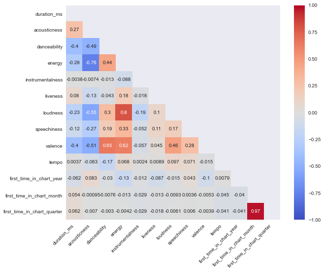

```python
plt.figure(figsize=(10,8))
# Compute the correlation matrix
corr = train_X.corr()

# Generate a mask for the upper triangle
mask = np.triu(np.ones_like(corr, dtype=np.bool))

ax = sns.heatmap(
    corr,
    mask=mask,
    vmin=-1, vmax=1, center=0,
    cmap='coolwarm',
    square=True,
    annot=True
)
ax.set_xticklabels(
    ax.get_xticklabels(),
    rotation=45,
    horizontalalignment='right'
);
```

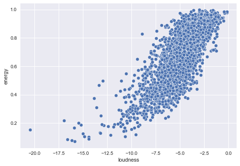

```python
sns.scatterplot(data=train_X, x="loudness", y="energy")
```

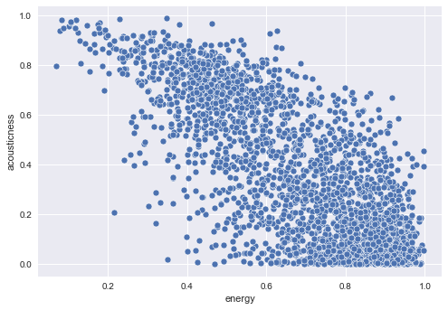

```python
sns.scatterplot(data=train_X, x="energy", y="acousticness")
```

### Correlación entre atributos categóricos y la clase

```python
# chi-square independence test
for f in cat_features:
    crosstab = pd.crosstab(train_X[f], train_y)
    _, p_value, _, _ = stats.chi2_contingency(crosstab)
    print(f"Feature {f} -- pValue {p_value}")
```

```
Feature is_collab -- pValue 0.6114747380495
Feature album_type -- pValue 0.013040020697266829
Feature explicit -- pValue 0.13013951903985735
Feature is_ost -- pValue 0.6450042375522845
Feature for_reality_tvshow -- pValue 0.5029994819681104
Feature first_time_in_chart_period -- pValue 0.584044228164895
```

### Correlación entre atributos numéricos y la clase

```python
# Kruskal-Wallis
for f in num_features:
    _, p_value = stats.kruskal(train_X[f], train_y)
    print(f"Feature {f} -- pValue {p_value}")
```

```
Feature duration_ms -- pValue 0.0
Feature acousticness -- pValue 3.953877216258122e-10
Feature danceability -- pValue 3.9538259803545885e-10
Feature energy -- pValue 3.9538491429104465e-10
Feature instrumentalness -- pValue 1.5281890855030158e-216
Feature liveness -- pValue 3.953659678455604e-10
Feature loudness -- pValue 0.0
Feature speechiness -- pValue 3.9538373208594897e-10
Feature valence -- pValue 3.953863613343442e-10
Feature tempo -- pValue 0.0
```

# Modelos de aprendizaje automático

```python
def backup(train_X, train_y, test_X, test_y):
    train_X.to_csv(f"{OUTPUT_FOLDER}train_X_temporal.csv", sep=";", index=False)
    train_y.to_csv(f"{OUTPUT_FOLDER}train_y_temporal.csv", sep=";", index=False)

    test_X.to_csv(f"{OUTPUT_FOLDER}test_X_temporal.csv", sep=";", index=False)
    test_y.to_csv(f"{OUTPUT_FOLDER}test_y_temporal.csv", sep=";", index=False)


def restore():
    train_X = pd.read_csv(f"{OUTPUT_FOLDER}train_X_temporal.csv", sep=";")
    train_y = pd.read_csv(f"{OUTPUT_FOLDER}train_y_temporal.csv", sep=";")

    test_X = pd.read_csv(f"{OUTPUT_FOLDER}test_X_temporal.csv", sep=";")
    test_y = pd.read_csv(f"{OUTPUT_FOLDER}test_y_temporal.csv", sep=";")

    return train_X, train_y, test_X, test_y
```

```python
CV_SPLITS = 3
```

Preparar los datos eligiendo solo los atributos pertinentes.

```python
train_X.drop(['title', 'singer', 'album', 'spotify_uri', 'first_time_in_chart_date',
              'first_time_in_chart_quarter'], axis=1, inplace=True)
test_X.drop(['title', 'singer', 'album', 'spotify_uri', 'first_time_in_chart_date',
             'first_time_in_chart_quarter'], axis=1, inplace=True)
```

```python
backup(train_X, train_y, test_X, test_y)
```

```python
train_X, train_y, test_X, test_y = restore()
```

Además se transforman los atributos categóricos de `producer` y `distributor` por la baja entropía que tienen.

```python
train_X['distributor'].value_counts(normalize=True)[:20]
```

```
카카오 m                              0.386965
stone music entertainment          0.194297
지니뮤직                               0.180448
dreamus                            0.050916
nhn벅스                              0.039511
universal music                    0.033401
sony music                         0.029735
지니뮤직, stone music entertainment    0.014257
warner music                       0.008554
yg plus                            0.006110
sm entertainment                   0.005703
다날                                 0.005703
미러볼뮤직                              0.005703
뮤직앤뉴                               0.005295
포니캐년코리아                            0.004481
인터파크                               0.003666
오감엔터테인먼트                           0.002444
에이앤지모즈                             0.002444
sbs 콘텐츠허브                          0.001629
루미넌트엔터테인먼트                         0.001629
Name: distributor, dtype: float64
```

```python
def group_low_categories(df_train, df_test, column, upper):
    categories_to_change = df_train[column].value_counts()[(df_train[column].value_counts(
        normalize=True) < upper)].index.to_list()
    df_train.loc[df_train[column].isin(categories_to_change), column] = "other"
    column_train_values = df_train[column].value_counts().index
    df_test.loc[~df_test[column].isin(column_train_values), column] = "other"
```

```python
group_low_categories(train_X, test_X, 'distributor', 0.10)
```

```python
train_X['distributor'].value_counts(normalize=True)[:20]
```

```
카카오 m                        0.386965
other                        0.238289
stone music entertainment    0.194297
지니뮤직                         0.180448
Name: distributor, dtype: float64
```

```python
train_X['producer'].value_counts(normalize=True)[:20]
```

```
sm entertainment             0.085132
yg entertainment             0.072505
stone music entertainment    0.054582
jyp entertainment            0.030957
큐브엔터테인먼트                     0.024847
카카오 m                        0.022811
아메바컬쳐                        0.020774
빅히트 엔터테인먼트                   0.020774
스타쉽엔터테인먼트                    0.015886
플레이엠엔터테인먼트                   0.014257
아이엠비씨                        0.013849
fnc엔터테인먼트                    0.013849
sbs 콘텐츠허브                    0.013442
코어컨텐츠미디어                     0.010591
플레디스                         0.010591
드림티 엔터테인먼트                   0.010591
젤리피쉬 엔터테인먼트                  0.010183
mbc                          0.010183
ymc엔터테인먼트                    0.008147
쇼파르뮤직                        0.007739
Name: producer, dtype: float64
```

```python
group_low_categories(train_X, test_X, 'producer', 0.03)
```

```python
train_X['producer'].value_counts(normalize=True)[:20]
```

```
other                        0.756823
sm entertainment             0.085132
yg entertainment             0.072505
stone music entertainment    0.054582
jyp entertainment            0.030957
Name: producer, dtype: float64
```

```python
backup(train_X, train_y, test_X, test_y)
```

```python
train_X, train_y, test_X, test_y = restore()
```

```python
train_y = train_y["is_popular"].to_list()
test_y = test_y["is_popular"].to_list()
```

Añadir atributo "artist has a previous popular song"

```python
class ArtistHasPreviousPopular(BaseEstimator, TransformerMixin):
    """Takes in dataframe and creates new features """

    def __init__(self, binary_features, add=True):
        self.add = add
        self.feature_name = "artist_before_popular" # feature name
        self.first_time_popular = None # datos transformados para poder añadir el campo
        self.desdoblada = None
        self.binary_features = binary_features # se pasa por referencia,
                                               # si el campo se añade se actualiza

    def transform(self, X, y=None):
        """The workhorse of this feature extractor"""
        if self.add is False:
            if self.feature_name in self.binary_features:
                self.binary_features.remove(self.feature_name)
            return X

        if self.first_time_popular is None:
            print("Fit the train data first!")
            return

        self.desdoblar(X, y)

        # transforming train or test
        self.first_time_popular.apply(lambda row: self.artist_before_popular_lambda(
            row, self.desdoblada),axis=1)

        X = X.copy()
        X[self.feature_name] = 0
        X.loc[self.desdoblada[
            self.desdoblada[self.feature_name] == 1].orig_index, self.feature_name] = 1

        # add feature to binary feature list
        if self.feature_name not in self.binary_features:
            self.binary_features.append(self.feature_name)

        return X

    def artist_before_popular_lambda(self, row, df):
        df.loc[(df.singer_id == row.singer_id) & (
               (df.first_time_in_chart_year > row.first_time_in_chart_year) |
               ((df.first_time_in_chart_month > row.first_time_in_chart_month) &
                (df.first_time_in_chart_year == row.first_time_in_chart_year))), self.feature_name] = 1

    def desdoblar(self, X, y=None):
        if y is None:
            tmp_y = -1
        else:
            tmp_y = y.copy()

        # transforming
        self.desdoblada = X.copy()
        self.desdoblada['orig_index'] = X.index
        self.desdoblada = self.desdoblada[['singer_id', 'first_time_in_chart_year', 'first_time_in_chart_month', 'orig_index']]
        self.desdoblada['popular'] = tmp_y

        # desdoblar cada singer id para que cada uno esté en una fila
        b = pd.DataFrame(self.desdoblada.singer_id.str.split('-sep-').tolist(), index=[
            self.desdoblada.first_time_in_chart_year, self.desdoblada.first_time_in_chart_month,
            self.desdoblada.popular, self.desdoblada.orig_index]).stack()
        b = b.reset_index()[[0, 'first_time_in_chart_year', 'first_time_in_chart_month','popular', 'orig_index']]
        b.columns = ['singer_id', 'first_time_in_chart_year', 'first_time_in_chart_month', 'popular', 'orig_index']
        self.desdoblada = b

    def fit(self, X, y=None):
        """Returns `self` unless something different happens in train and test"""
        if self.add is False:
            # check if the name of the feature is in the list and delete it if so
            if self.feature_name in self.binary_features:
                self.binary_features.remove(self.feature_name)
            return self

        self.desdoblar(X, y)

        # solo con train
        self.first_time_popular = self.desdoblada.sort_values(['first_time_in_chart_year',
                                                     'first_time_in_chart_month'],
                                                    ascending=True)
        self.first_time_popular = self.first_time_popular[(self.first_time_popular.popular == 1)].drop_duplicates(
            'singer_id')
        return self
```

```python
a= ArtistHasPreviousPopular(binary_features)
a.fit(train_X, train_y)
b = a.transform(train_X, train_y)
```

```python
train_X.shape
```

```
(2455, 21)
```

```python
b.shape
```

```
(2455, 22)
```

```python
b['popular'] = train_y
b[b.singer_id=="3cjEqqelV9zb4BYE3qDQ4O"][['first_time_in_chart_year', 'first_time_in_chart_month', 'singer_id',
                                          'artist_before_popular', 'popular']].sort_values(
    ['first_time_in_chart_year', 'first_time_in_chart_month'],
                                                    ascending=True).head(9)
```

|  | first_time_in_chart_year | first_time_in_chart_month | singer_id | artist_before_popular | popular |
| --- | --- | --- | --- | --- | --- |
| 1156 | 2013 | 6 | 3cjEqqelV9zb4BYE3qDQ4O | 0 | 0 |
| 408 | 2013 | 8 | 3cjEqqelV9zb4BYE3qDQ4O | 0 | 1 |
| 329 | 2013 | 12 | 3cjEqqelV9zb4BYE3qDQ4O | 1 | 1 |
| 827 | 2015 | 1 | 3cjEqqelV9zb4BYE3qDQ4O | 1 | 0 |
| 643 | 2015 | 3 | 3cjEqqelV9zb4BYE3qDQ4O | 1 | 1 |
| 877 | 2015 | 4 | 3cjEqqelV9zb4BYE3qDQ4O | 1 | 0 |
| 1122 | 2015 | 4 | 3cjEqqelV9zb4BYE3qDQ4O | 1 | 0 |
| 1597 | 2015 | 4 | 3cjEqqelV9zb4BYE3qDQ4O | 1 | 0 |
| 1057 | 2015 | 6 | 3cjEqqelV9zb4BYE3qDQ4O | 1 | 0 |

```python
class PassThrough(BaseEstimator, TransformerMixin):
    """Takes in dataframe and creates new features """

    def transform(self, X, y=None):
        """The workhorse of this feature extractor"""
        return X

    def fit(self, X, y=None):
        return self
```

```python
scoring = ["accuracy", "precision", "recall", "f1"]
def define_pipeline(categorical_pipeline='default', binary_pipeline=None,
                    numerical_pipeline='default', model=None, artist_feature=True):
    numeric_features_aux = numeric_features
    binary_features_aux = binary_features
    categorical_features_aux = categorical_features

    # Categorical features
    if not categorical_pipeline or categorical_pipeline == "remove":
        categorical_transformer = Pipeline([
                ('cat_pass', PassThrough()),
            ])
    elif categorical_pipeline == 'default':
        # default
        categorical_transformer = Pipeline([
            ('one_hot_encoder', OneHotEncoder(handle_unknown='ignore')),
        ])
    else:
        categorical_transformer = categorical_pipeline

    if categorical_pipeline == 'remove':
        categorical_features_aux = []

    # Numerical features
    if not numerical_pipeline or numerical_pipeline == 'remove':
        numerical_transformer = Pipeline([
                ('num_pass', PassThrough()),
            ])
    elif numerical_pipeline == "default":
        # default
        numerical_transformer = Pipeline([
            ('scaler', StandardScaler()),
        ])
    else:
        numerical_transformer = numerical_pipeline

    if numerical_pipeline == 'remove':
        numerical_features_aux = []

    # Binary features
    if not binary_pipeline or binary_pipeline == "remove":
        binary_transformer =  Pipeline([
                ('pass', PassThrough()),
            ])
    else:
        binary_transformer =  binary_pipeline

    if binary_pipeline == 'remove':
        binary_features_aux = []

    preprocessor = ColumnTransformer(
        transformers=[
            ('num', numerical_transformer, numeric_features_aux),
            ('binary', binary_transformer, binary_features_aux),
            ('cat', categorical_transformer, categorical_features_aux)])

    clf_preprocess = Pipeline(steps=[
                          ('add_feature_previous_popular', ArtistHasPreviousPopular(binary_features, add=artist_feature)),
                          ('preprocessor', preprocessor)])

    if model is not None:
        clf = Pipeline(steps = [
                              ('preprocess', clf_preprocess),
                              ('classifier', model)])
    else:
        clf = clf_preprocess

    return clf

def define_pipeline_and_optimize(categorical_pipeline='default', binary_pipeline=None,
                                 numerical_pipeline='default', model_grid_values={},
                                 custom_grid_values={}, model=None, artist_feature=True):

    grid_values = {**model_grid_values, **custom_grid_values}

    clf = define_pipeline(categorical_pipeline, binary_pipeline, numerical_pipeline,
                          model, artist_feature)

    # optimize precision and monitor the scoring
    best = GridSearchCV(clf, grid_values, cv=CV_SPLITS, refit='precision', scoring=scoring,
                        return_train_score=True)
    best.fit(train_X, train_y)

    # print metrics
    print(best.best_params_)
    best_scores = pd.DataFrame(best.cv_results_)
    for k,v in best.best_params_.items():
        best_scores = best_scores[best_scores["param_" + k] == v]

    for s in scoring:
        print(f"{s}: %0.2f" % (best_scores["mean_test_" + s]))

    return best.best_estimator_
```

```python
def plot_learning_curves(pipeline, train_X, train_y, cv=CV_SPLITS, scoring='precision'):
    train_sizes, train_scores, valid_scores = learning_curve(pipeline, train_X,
                                                         train_y, cv=cv, scoring=scoring)
    train_scores_mean = train_scores.mean(axis = 1)
    validation_scores_mean = valid_scores.mean(axis = 1)
    plt.plot(train_sizes, train_scores_mean, label = f'Training {scoring}')
    plt.plot(train_sizes, validation_scores_mean, label = f'Validation {scoring}')
    plt.ylabel(scoring, fontsize = 14)
    plt.xlabel('Training set size', fontsize = 14)
    plt.title('Learning curves for model', fontsize = 18, y = 1.03)
    plt.legend()
    plt.show()
```

```python
# first define the column types of the data
categorical_features = ['producer', 'distributor', 'album_type', 'first_time_in_chart_period']
other_features = ['singer_id']
binary_features = ["is_collab", "explicit", "is_ost", "for_reality_tvshow"]
numeric_features = list(train_X.columns.difference(other_features).difference(categorical_features).difference(binary_features))
```

## Logistic Regression

Los modelos mostrados en esta sección también se probaron utilizando los datos no estratificados, pero como era prácticamente iguales se decidió intentar mejorar los estratificados, ya que presentaban mayor balance en la clase.

### 1. Baseline

Se prueban los modelos escogidos solo con datos numéricos para tener un baseline con el que comparar resultados más tarde.

```python
def cross_validation(clf, train_X, train_y, cv=CV_SPLITS):
    scoring = {'accuracy': 'accuracy',
           'precision': 'precision',
           'recall': 'recall',
           'f1':'f1'}
    scores = cross_validate(clf, train_X, train_y, cv=CV_SPLITS,
                            scoring=scoring, n_jobs = -1)
    for k,v in scores.items():
        print(f"{k}: %0.2f (+/- %0.2f)" % (v.mean(), v.std() * 2))
```

```python
numeric_train = train_X[numeric_features]
numeric_test = test_X[numeric_features]
```

```python
baseline_logistic = LogisticRegression(random_state=42, penalty='none')
cross_validation(baseline_logistic, numeric_train, train_y)
```

```
fit_time: 0.42 (+/- 0.00)
score_time: 0.01 (+/- 0.00)
test_accuracy: 0.55 (+/- 0.00)
test_precision: 0.55 (+/- 0.00)
test_recall: 1.00 (+/- 0.00)
test_f1: 0.71 (+/- 0.00)
```

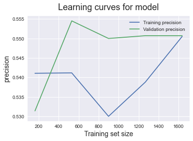

```python
plot_learning_curves(baseline_logistic, numeric_train, train_y)
```

También se probó con RobustScaler.

### 2. Atributos numéricos + categóricos One Hot Encoding + Standarized

```python
all_features = define_pipeline(model=LogisticRegression(random_state=42,  penalty='none'),
                           artist_feature=False)

cross_validation(all_features, train_X, train_y)
```

```
fit_time: 0.05 (+/- 0.01)
score_time: 0.02 (+/- 0.00)
test_accuracy: 0.58 (+/- 0.02)
test_precision: 0.59 (+/- 0.02)
test_recall: 0.75 (+/- 0.03)
test_f1: 0.66 (+/- 0.01)
```

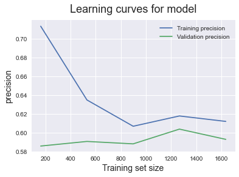

```python
plot_learning_curves(all_features, train_X, train_y)
```

### 3. Atributos numéricos + categóricos One Hot Encoding + Standarized + Polinomial Gridsearch + new atribute

```python
best_models = {"with_reg": None, "without_reg": None}
for b in best_models.keys():
    if b == "with_reg":
        logistic_grid_values = {
                 'classifier__penalty': ['l2'],
                 'classifier__C': [0.0001, 0.001,0.01]
        }
    else:
        logistic_grid_values = {
                 'classifier__penalty': ['none']
        }

    numerical_grid_values = {'preprocess__preprocessor__num__poly_features__degree': [1, 2, 3]}

    numerical_transformer = Pipeline([
            ("poly_features", PolynomialFeatures(interaction_only=True)),
            ('scaler', StandardScaler()),
        ])

    print(b)
    poly_best_cv = define_pipeline_and_optimize(numerical_pipeline=numerical_transformer,
                                                model_grid_values=logistic_grid_values,
                                                custom_grid_values=numerical_grid_values,
                                                model=LogisticRegression(random_state=42))
    best_models[b] = poly_best_cv
    print()
```

```
with_reg
{'classifier__C': 0.01, 'classifier__penalty': 'l2', 'preprocess__preprocessor__num__poly_features__degree': 2}
accuracy: 0.58
precision: 0.59
recall: 0.80
f1: 0.68

without_reg
{'classifier__penalty': 'none', 'preprocess__preprocessor__num__poly_features__degree': 3}
accuracy: 0.57
precision: 0.60
recall: 0.69
f1: 0.64
```

```
with_reg
```

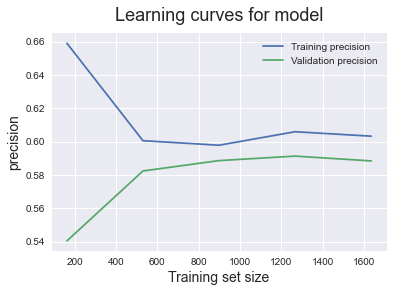

```
without_reg
```

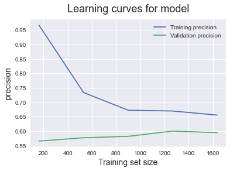

```python
for k,v in best_models.items():
    print(k)
    plot_learning_curves(v, train_X, train_y)
    v.fit(train_X, train_y)
    print()
```

```python
poly_best_cv = best_models["without_reg"]
```